# Risk Factor Analysis

## Outcome Variable

**Outcome Variable:** ever_wasted

## Predictor Variables

**Intervention Variable:** predfeed3

**Adjustment Set:**

- arm
- sex
- month
- brthmon
- W_mage
- meducyrs
- feducyrs
- hhwealth_quart
- hfoodsec
- W_mhtcm
- vagbrth
- W_gagebrth
- W_birthwt
- W_birthlen
- W_nrooms
- W_nchldlt5
- W_parity
- impfloor
- impsan
- safeh20
- delta_W_mage
- delta_meducyrs
- delta_feducyrs
- delta_hhwealth_quart
- delta_hfoodsec
- delta_W_mhtcm
- delta_vagbrth
- delta_W_gagebrth
- delta_W_birthwt
- delta_W_birthlen
- delta_W_nrooms
- delta_W_nchldlt5
- delta_W_parity
- delta_impfloor
- delta_impsan
- delta_safeh20

## Stratifying Variables

The analysis was stratified on these variable(s):

- agecat
- studyid
- country

## Data Summary

| agecat | studyid | country | predfeed3 | ever_wasted | n_cell | n |
| --- | --- | --- | --- | --- | --- | --- |
| 0-24 months (no birth wast) | ki0047075b-MAL-ED | BANGLADESH | 1 | 0 | 162 | 248 |
| 0-24 months (no birth wast) | ki0047075b-MAL-ED | BANGLADESH | 1 | 1 | 51 | 248 |
| 0-24 months (no birth wast) | ki0047075b-MAL-ED | BANGLADESH | 0 | 0 | 31 | 248 |
| 0-24 months (no birth wast) | ki0047075b-MAL-ED | BANGLADESH | 0 | 1 | 4 | 248 |
| 0-24 months (no birth wast) | ki0047075b-MAL-ED | BRAZIL | 1 | 0 | 113 | 224 |
| 0-24 months (no birth wast) | ki0047075b-MAL-ED | BRAZIL | 1 | 1 | 7 | 224 |
| 0-24 months (no birth wast) | ki0047075b-MAL-ED | BRAZIL | 0 | 0 | 99 | 224 |
| 0-24 months (no birth wast) | ki0047075b-MAL-ED | BRAZIL | 0 | 1 | 5 | 224 |
| 0-24 months (no birth wast) | ki0047075b-MAL-ED | INDIA | 1 | 0 | 118 | 235 |
| 0-24 months (no birth wast) | ki0047075b-MAL-ED | INDIA | 1 | 1 | 63 | 235 |
| 0-24 months (no birth wast) | ki0047075b-MAL-ED | INDIA | 0 | 0 | 29 | 235 |
| 0-24 months (no birth wast) | ki0047075b-MAL-ED | INDIA | 0 | 1 | 25 | 235 |
| 0-24 months (no birth wast) | ki0047075b-MAL-ED | NEPAL | 1 | 0 | 105 | 234 |
| 0-24 months (no birth wast) | ki0047075b-MAL-ED | NEPAL | 1 | 1 | 28 | 234 |
| 0-24 months (no birth wast) | ki0047075b-MAL-ED | NEPAL | 0 | 0 | 84 | 234 |
| 0-24 months (no birth wast) | ki0047075b-MAL-ED | NEPAL | 0 | 1 | 17 | 234 |
| 0-24 months (no birth wast) | ki0047075b-MAL-ED | PERU | 1 | 0 | 183 | 286 |
| 0-24 months (no birth wast) | ki0047075b-MAL-ED | PERU | 1 | 1 | 11 | 286 |
| 0-24 months (no birth wast) | ki0047075b-MAL-ED | PERU | 0 | 0 | 84 | 286 |
| 0-24 months (no birth wast) | ki0047075b-MAL-ED | PERU | 0 | 1 | 8 | 286 |
| 0-24 months (no birth wast) | ki0047075b-MAL-ED | SOUTH AFRICA | 1 | 0 | 79 | 275 |
| 0-24 months (no birth wast) | ki0047075b-MAL-ED | SOUTH AFRICA | 1 | 1 | 16 | 275 |
| 0-24 months (no birth wast) | ki0047075b-MAL-ED | SOUTH AFRICA | 0 | 0 | 152 | 275 |
| 0-24 months (no birth wast) | ki0047075b-MAL-ED | SOUTH AFRICA | 0 | 1 | 28 | 275 |
| 0-24 months (no birth wast) | ki0047075b-MAL-ED | TANZANIA, UNITED REPUBLIC OF | 1 | 0 | 83 | 249 |
| 0-24 months (no birth wast) | ki0047075b-MAL-ED | TANZANIA, UNITED REPUBLIC OF | 1 | 1 | 9 | 249 |
| 0-24 months (no birth wast) | ki0047075b-MAL-ED | TANZANIA, UNITED REPUBLIC OF | 0 | 0 | 136 | 249 |
| 0-24 months (no birth wast) | ki0047075b-MAL-ED | TANZANIA, UNITED REPUBLIC OF | 0 | 1 | 21 | 249 |
| 0-24 months (no birth wast) | ki1000109-EE | PAKISTAN | 1 | 0 | 199 | 376 |
| 0-24 months (no birth wast) | ki1000109-EE | PAKISTAN | 1 | 1 | 151 | 376 |

[output cut: 102 more lines]

The following strata were considered:

- agecat: 0-24 months (no birth wast), studyid: ki0047075b-MAL-ED, country: BANGLADESH
- agecat: 0-24 months (no birth wast), studyid: ki0047075b-MAL-ED, country: BRAZIL
- agecat: 0-24 months (no birth wast), studyid: ki0047075b-MAL-ED, country: INDIA
- agecat: 0-24 months (no birth wast), studyid: ki0047075b-MAL-ED, country: NEPAL
- agecat: 0-24 months (no birth wast), studyid: ki0047075b-MAL-ED, country: PERU
- agecat: 0-24 months (no birth wast), studyid: ki0047075b-MAL-ED, country: SOUTH AFRICA
- agecat: 0-24 months (no birth wast), studyid: ki0047075b-MAL-ED, country: TANZANIA, UNITED REPUBLIC OF
- agecat: 0-24 months (no birth wast), studyid: ki1000109-EE, country: PAKISTAN
- agecat: 0-24 months (no birth wast), studyid: ki1113344-GMS-Nepal, country: NEPAL
- agecat: 0-24 months (no birth wast), studyid: kiGH5241-JiVitA-3, country: BANGLADESH
- agecat: 0-24 months (no birth wast), studyid: kiGH5241-JiVitA-4, country: BANGLADESH
- agecat: 0-6 months (no birth wast), studyid: ki0047075b-MAL-ED, country: BANGLADESH
- agecat: 0-6 months (no birth wast), studyid: ki0047075b-MAL-ED, country: BRAZIL
- agecat: 0-6 months (no birth wast), studyid: ki0047075b-MAL-ED, country: INDIA
- agecat: 0-6 months (no birth wast), studyid: ki0047075b-MAL-ED, country: NEPAL
- agecat: 0-6 months (no birth wast), studyid: ki0047075b-MAL-ED, country: PERU
- agecat: 0-6 months (no birth wast), studyid: ki0047075b-MAL-ED, country: SOUTH AFRICA
- agecat: 0-6 months (no birth wast), studyid: ki0047075b-MAL-ED, country: TANZANIA, UNITED REPUBLIC OF
- agecat: 0-6 months (no birth wast), studyid: ki1000109-EE, country: PAKISTAN
- agecat: 0-6 months (no birth wast), studyid: ki1113344-GMS-Nepal, country: NEPAL
- agecat: 0-6 months (no birth wast), studyid: kiGH5241-JiVitA-3, country: BANGLADESH
- agecat: 0-6 months (no birth wast), studyid: kiGH5241-JiVitA-4, country: BANGLADESH
- agecat: 6-24 months, studyid: ki0047075b-MAL-ED, country: BANGLADESH
- agecat: 6-24 months, studyid: ki0047075b-MAL-ED, country: BRAZIL
- agecat: 6-24 months, studyid: ki0047075b-MAL-ED, country: INDIA
- agecat: 6-24 months, studyid: ki0047075b-MAL-ED, country: NEPAL
- agecat: 6-24 months, studyid: ki0047075b-MAL-ED, country: PERU
- agecat: 6-24 months, studyid: ki0047075b-MAL-ED, country: SOUTH AFRICA
- agecat: 6-24 months, studyid: ki0047075b-MAL-ED, country: TANZANIA, UNITED REPUBLIC OF
- agecat: 6-24 months, studyid: ki1000109-EE, country: PAKISTAN
- agecat: 6-24 months, studyid: ki1113344-GMS-Nepal, country: NEPAL
- agecat: 6-24 months, studyid: kiGH5241-JiVitA-3, country: BANGLADESH
- agecat: 6-24 months, studyid: kiGH5241-JiVitA-4, country: BANGLADESH

### Dropped Strata

Some strata were dropped due to rare outcomes:

- agecat: 0-24 months (no birth wast), studyid: ki0047075b-MAL-ED, country: BANGLADESH
- agecat: 0-24 months (no birth wast), studyid: kiGH5241-JiVitA-4, country: BANGLADESH
- agecat: 0-6 months (no birth wast), studyid: ki0047075b-MAL-ED, country: BANGLADESH
- agecat: 0-6 months (no birth wast), studyid: ki0047075b-MAL-ED, country: BRAZIL
- agecat: 0-6 months (no birth wast), studyid: ki0047075b-MAL-ED, country: PERU
- agecat: 0-6 months (no birth wast), studyid: ki0047075b-MAL-ED, country: TANZANIA, UNITED REPUBLIC OF
- agecat: 0-6 months (no birth wast), studyid: kiGH5241-JiVitA-4, country: BANGLADESH
- agecat: 6-24 months, studyid: ki0047075b-MAL-ED, country: BANGLADESH
- agecat: 6-24 months, studyid: ki0047075b-MAL-ED, country: BRAZIL
- agecat: 6-24 months, studyid: kiGH5241-JiVitA-4, country: BANGLADESH

## Methods Detail

We’re interested in the causal parameters $E[Y_a]$ for all values of $a \in \mathcal{A}$. These parameters represent the mean outcome if, possibly contrary to fact, we intervened to set all units to have $A=a$. Under the randomization and positivity assumptions, these are identified by the statistical parameters $\psi_a=E_W[E_{Y|A,W}(Y|A=a,W)]$. In addition, we’re interested in the mean of $Y$, $E[Y]$ under no intervention (the observed mean). We will estimate these parameters by using SuperLearner to fit the relevant likelihood factors – $E_{Y|A,W}(Y|A=a,W)$ and $p(A=a|W)$, and then updating our likelihood fit using a joint TMLE.

For unadjusted analyses ($W=\{\}$), initial likelihoods were estimated using Lrnr_glm to estimate the simple $E(Y|A)$ and Lrnr_mean to estimate $p(A)$. For adjusted analyses, a small library containing Lrnr_glmnet, Lrnr_xgboost, and Lrnr_mean was used.

Having estimated these parameters, we will then use the delta method to estimate relative risks and attributable risks relative to a prespecified baseline level of $A$.

# Results Detail

## Results Plots

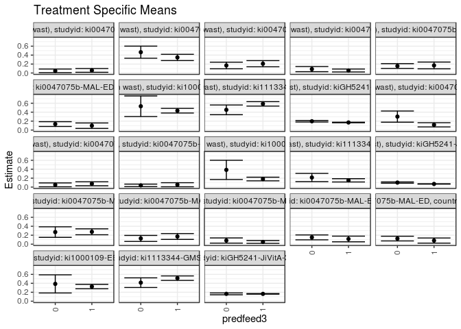

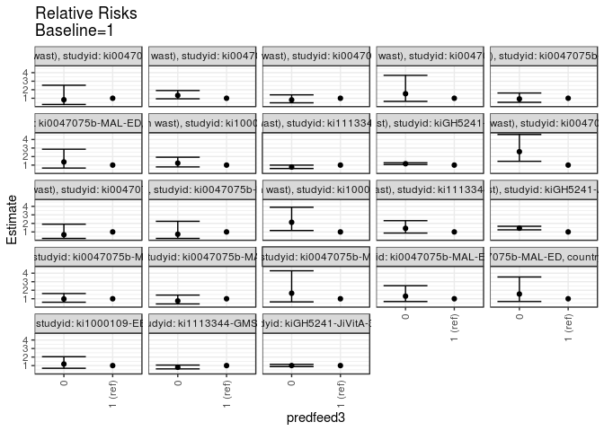

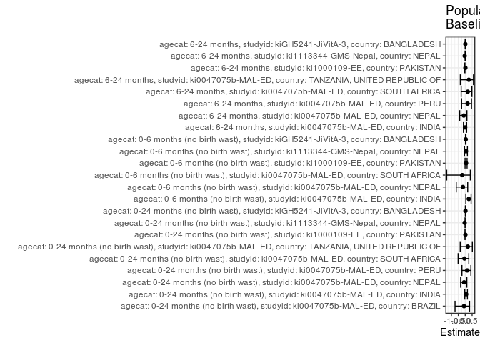

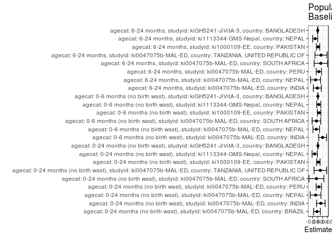

## Results Table

### Parameter: TSM

| agecat | studyid | country | intervention_level | baseline_level | estimate | ci_lower | ci_upper |
| --- | --- | --- | --- | --- | --- | --- | --- |
| 0-24 months (no birth wast) | ki0047075b-MAL-ED | BRAZIL | 1 | NA | 0.0583333 | 0.0163056 | 0.1003611 |
| 0-24 months (no birth wast) | ki0047075b-MAL-ED | BRAZIL | 0 | NA | 0.0480769 | 0.0068698 | 0.0892840 |
| 0-24 months (no birth wast) | ki0047075b-MAL-ED | INDIA | 1 | NA | 0.3482009 | 0.2784364 | 0.4179655 |
| 0-24 months (no birth wast) | ki0047075b-MAL-ED | INDIA | 0 | NA | 0.4653986 | 0.3300373 | 0.6007598 |
| 0-24 months (no birth wast) | ki0047075b-MAL-ED | NEPAL | 1 | NA | 0.2082299 | 0.1390700 | 0.2773898 |
| 0-24 months (no birth wast) | ki0047075b-MAL-ED | NEPAL | 0 | NA | 0.1684402 | 0.0944198 | 0.2424606 |
| 0-24 months (no birth wast) | ki0047075b-MAL-ED | PERU | 1 | NA | 0.0567010 | 0.0241003 | 0.0893018 |
| 0-24 months (no birth wast) | ki0047075b-MAL-ED | PERU | 0 | NA | 0.0869565 | 0.0292783 | 0.1446347 |
| 0-24 months (no birth wast) | ki0047075b-MAL-ED | SOUTH AFRICA | 1 | NA | 0.1692564 | 0.0936571 | 0.2448556 |
| 0-24 months (no birth wast) | ki0047075b-MAL-ED | SOUTH AFRICA | 0 | NA | 0.1559367 | 0.1027957 | 0.2090776 |
| 0-24 months (no birth wast) | ki0047075b-MAL-ED | TANZANIA, UNITED REPUBLIC OF | 1 | NA | 0.0978261 | 0.0369985 | 0.1586537 |
| 0-24 months (no birth wast) | ki0047075b-MAL-ED | TANZANIA, UNITED REPUBLIC OF | 0 | NA | 0.1337580 | 0.0804059 | 0.1871101 |
| 0-24 months (no birth wast) | ki1000109-EE | PAKISTAN | 1 | NA | 0.4328149 | 0.3807320 | 0.4848978 |
| 0-24 months (no birth wast) | ki1000109-EE | PAKISTAN | 0 | NA | 0.5322404 | 0.3022546 | 0.7622262 |
| 0-24 months (no birth wast) | ki1113344-GMS-Nepal | NEPAL | 1 | NA | 0.5855390 | 0.5361551 | 0.6349229 |
| 0-24 months (no birth wast) | ki1113344-GMS-Nepal | NEPAL | 0 | NA | 0.4521731 | 0.3434940 | 0.5608521 |
| 0-24 months (no birth wast) | kiGH5241-JiVitA-3 | BANGLADESH | 1 | NA | 0.1694280 | 0.1637777 | 0.1750783 |
| 0-24 months (no birth wast) | kiGH5241-JiVitA-3 | BANGLADESH | 0 | NA | 0.1965749 | 0.1793034 | 0.2138464 |
| 0-6 months (no birth wast) | ki0047075b-MAL-ED | INDIA | 1 | NA | 0.1170008 | 0.0700863 | 0.1639153 |
| 0-6 months (no birth wast) | ki0047075b-MAL-ED | INDIA | 0 | NA | 0.3009777 | 0.1759293 | 0.4260260 |
| 0-6 months (no birth wast) | ki0047075b-MAL-ED | NEPAL | 1 | NA | 0.0751880 | 0.0302761 | 0.1200998 |
| 0-6 months (no birth wast) | ki0047075b-MAL-ED | NEPAL | 0 | NA | 0.0505051 | 0.0072753 | 0.0937348 |
| 0-6 months (no birth wast) | ki0047075b-MAL-ED | SOUTH AFRICA | 1 | NA | 0.0531915 | 0.0077419 | 0.0986411 |
| 0-6 months (no birth wast) | ki0047075b-MAL-ED | SOUTH AFRICA | 0 | NA | 0.0388889 | 0.0105942 | 0.0671836 |
| 0-6 months (no birth wast) | ki1000109-EE | PAKISTAN | 1 | NA | 0.1808652 | 0.1402219 | 0.2215084 |
| 0-6 months (no birth wast) | ki1000109-EE | PAKISTAN | 0 | NA | 0.3851687 | 0.1696419 | 0.6006955 |
| 0-6 months (no birth wast) | ki1113344-GMS-Nepal | NEPAL | 1 | NA | 0.1512199 | 0.1147193 | 0.1877205 |
| 0-6 months (no birth wast) | ki1113344-GMS-Nepal | NEPAL | 0 | NA | 0.2144471 | 0.1224075 | 0.3064867 |
| 0-6 months (no birth wast) | kiGH5241-JiVitA-3 | BANGLADESH | 1 | NA | 0.0705374 | 0.0666249 | 0.0744500 |
| 0-6 months (no birth wast) | kiGH5241-JiVitA-3 | BANGLADESH | 0 | NA | 0.1013709 | 0.0875308 | 0.1152109 |
| 6-24 months | ki0047075b-MAL-ED | INDIA | 1 | NA | 0.2761991 | 0.2099725 | 0.3424256 |
| 6-24 months | ki0047075b-MAL-ED | INDIA | 0 | NA | 0.2703264 | 0.1525001 | 0.3881528 |
| 6-24 months | ki0047075b-MAL-ED | NEPAL | 1 | NA | 0.1715995 | 0.1063339 | 0.2368651 |
| 6-24 months | ki0047075b-MAL-ED | NEPAL | 0 | NA | 0.1281828 | 0.0611252 | 0.1952405 |
| 6-24 months | ki0047075b-MAL-ED | PERU | 1 | NA | 0.0494505 | 0.0178935 | 0.0810076 |
| 6-24 months | ki0047075b-MAL-ED | PERU | 0 | NA | 0.0813953 | 0.0234959 | 0.1392948 |
| 6-24 months | ki0047075b-MAL-ED | SOUTH AFRICA | 1 | NA | 0.1159821 | 0.0524335 | 0.1795306 |
| 6-24 months | ki0047075b-MAL-ED | SOUTH AFRICA | 0 | NA | 0.1514752 | 0.0967775 | 0.2061729 |
| 6-24 months | ki0047075b-MAL-ED | TANZANIA, UNITED REPUBLIC OF | 1 | NA | 0.0804598 | 0.0231836 | 0.1377359 |
| 6-24 months | ki0047075b-MAL-ED | TANZANIA, UNITED REPUBLIC OF | 0 | NA | 0.1250000 | 0.0723139 | 0.1776861 |
| 6-24 months | ki1000109-EE | PAKISTAN | 1 | NA | 0.3272391 | 0.2777765 | 0.3767017 |
| 6-24 months | ki1000109-EE | PAKISTAN | 0 | NA | 0.3869146 | 0.1843789 | 0.5894504 |
| 6-24 months | ki1113344-GMS-Nepal | NEPAL | 1 | NA | 0.5150207 | 0.4651223 | 0.5649192 |
| 6-24 months | ki1113344-GMS-Nepal | NEPAL | 0 | NA | 0.4145883 | 0.3067808 | 0.5223957 |
| 6-24 months | kiGH5241-JiVitA-3 | BANGLADESH | 1 | NA | 0.1636848 | 0.1572188 | 0.1701507 |
| 6-24 months | kiGH5241-JiVitA-3 | BANGLADESH | 0 | NA | 0.1645335 | 0.1437998 | 0.1852672 |

### Parameter: E(Y)

| agecat | studyid | country | intervention_level | baseline_level | estimate | ci_lower | ci_upper |
| --- | --- | --- | --- | --- | --- | --- | --- |
| 0-24 months (no birth wast) | ki0047075b-MAL-ED | BRAZIL | NA | NA | 0.0535714 | 0.0240181 | 0.0831247 |
| 0-24 months (no birth wast) | ki0047075b-MAL-ED | INDIA | NA | NA | 0.3744681 | 0.3124566 | 0.4364796 |
| 0-24 months (no birth wast) | ki0047075b-MAL-ED | NEPAL | NA | NA | 0.1923077 | 0.1417029 | 0.2429125 |
| 0-24 months (no birth wast) | ki0047075b-MAL-ED | PERU | NA | NA | 0.0664336 | 0.0375206 | 0.0953465 |
| 0-24 months (no birth wast) | ki0047075b-MAL-ED | SOUTH AFRICA | NA | NA | 0.1600000 | 0.1165917 | 0.2034083 |
| 0-24 months (no birth wast) | ki0047075b-MAL-ED | TANZANIA, UNITED REPUBLIC OF | NA | NA | 0.1204819 | 0.0799679 | 0.1609960 |
| 0-24 months (no birth wast) | ki1000109-EE | PAKISTAN | NA | NA | 0.4388298 | 0.3886039 | 0.4890557 |
| 0-24 months (no birth wast) | ki1113344-GMS-Nepal | NEPAL | NA | NA | 0.5622318 | 0.5171396 | 0.6073240 |
| 0-24 months (no birth wast) | kiGH5241-JiVitA-3 | BANGLADESH | NA | NA | 0.1725236 | 0.1670497 | 0.1779975 |
| 0-6 months (no birth wast) | ki0047075b-MAL-ED | INDIA | NA | NA | 0.1581197 | 0.1112720 | 0.2049674 |
| 0-6 months (no birth wast) | ki0047075b-MAL-ED | NEPAL | NA | NA | 0.0646552 | 0.0329427 | 0.0963676 |
| 0-6 months (no birth wast) | ki0047075b-MAL-ED | SOUTH AFRICA | NA | NA | 0.0437956 | 0.0195207 | 0.0680705 |
| 0-6 months (no birth wast) | ki1000109-EE | PAKISTAN | NA | NA | 0.1935484 | 0.1533466 | 0.2337501 |
| 0-6 months (no birth wast) | ki1113344-GMS-Nepal | NEPAL | NA | NA | 0.1607143 | 0.1266675 | 0.1947611 |
| 0-6 months (no birth wast) | kiGH5241-JiVitA-3 | BANGLADESH | NA | NA | 0.0732993 | 0.0695038 | 0.0770947 |
| 6-24 months | ki0047075b-MAL-ED | INDIA | NA | NA | 0.2746781 | 0.2172425 | 0.3321138 |
| 6-24 months | ki0047075b-MAL-ED | NEPAL | NA | NA | 0.1551724 | 0.1084814 | 0.2018634 |
| 6-24 months | ki0047075b-MAL-ED | PERU | NA | NA | 0.0597015 | 0.0312819 | 0.0881211 |
| 6-24 months | ki0047075b-MAL-ED | SOUTH AFRICA | NA | NA | 0.1422925 | 0.0991596 | 0.1854254 |
| 6-24 months | ki0047075b-MAL-ED | TANZANIA, UNITED REPUBLIC OF | NA | NA | 0.1087866 | 0.0692283 | 0.1483450 |
| 6-24 months | ki1000109-EE | PAKISTAN | NA | NA | 0.3315508 | 0.2837756 | 0.3793260 |
| 6-24 months | ki1113344-GMS-Nepal | NEPAL | NA | NA | 0.4957265 | 0.4503800 | 0.5410730 |
| 6-24 months | kiGH5241-JiVitA-3 | BANGLADESH | NA | NA | 0.1648726 | 0.1585930 | 0.1711523 |

### Parameter: RR

| agecat | studyid | country | intervention_level | baseline_level | estimate | ci_lower | ci_upper |
| --- | --- | --- | --- | --- | --- | --- | --- |
| 0-24 months (no birth wast) | ki0047075b-MAL-ED | BRAZIL | 1 | 1 | 1.0000000 | 1.0000000 | 1.0000000 |
| 0-24 months (no birth wast) | ki0047075b-MAL-ED | BRAZIL | 0 | 1 | 0.8241758 | 0.2689937 | 2.5252112 |
| 0-24 months (no birth wast) | ki0047075b-MAL-ED | INDIA | 1 | 1 | 1.0000000 | 1.0000000 | 1.0000000 |
| 0-24 months (no birth wast) | ki0047075b-MAL-ED | INDIA | 0 | 1 | 1.3365804 | 0.9385695 | 1.9033724 |
| 0-24 months (no birth wast) | ki0047075b-MAL-ED | NEPAL | 1 | 1 | 1.0000000 | 1.0000000 | 1.0000000 |
| 0-24 months (no birth wast) | ki0047075b-MAL-ED | NEPAL | 0 | 1 | 0.8089148 | 0.4679545 | 1.3983050 |
| 0-24 months (no birth wast) | ki0047075b-MAL-ED | PERU | 1 | 1 | 1.0000000 | 1.0000000 | 1.0000000 |
| 0-24 months (no birth wast) | ki0047075b-MAL-ED | PERU | 0 | 1 | 1.5335968 | 0.6375068 | 3.6892459 |
| 0-24 months (no birth wast) | ki0047075b-MAL-ED | SOUTH AFRICA | 1 | 1 | 1.0000000 | 1.0000000 | 1.0000000 |
| 0-24 months (no birth wast) | ki0047075b-MAL-ED | SOUTH AFRICA | 0 | 1 | 0.9213046 | 0.5248025 | 1.6173747 |
| 0-24 months (no birth wast) | ki0047075b-MAL-ED | TANZANIA, UNITED REPUBLIC OF | 1 | 1 | 1.0000000 | 1.0000000 | 1.0000000 |
| 0-24 months (no birth wast) | ki0047075b-MAL-ED | TANZANIA, UNITED REPUBLIC OF | 0 | 1 | 1.3673036 | 0.6531876 | 2.8621470 |
| 0-24 months (no birth wast) | ki1000109-EE | PAKISTAN | 1 | 1 | 1.0000000 | 1.0000000 | 1.0000000 |
| 0-24 months (no birth wast) | ki1000109-EE | PAKISTAN | 0 | 1 | 1.2297183 | 0.7857352 | 1.9245760 |
| 0-24 months (no birth wast) | ki1113344-GMS-Nepal | NEPAL | 1 | 1 | 1.0000000 | 1.0000000 | 1.0000000 |
| 0-24 months (no birth wast) | ki1113344-GMS-Nepal | NEPAL | 0 | 1 | 0.7722339 | 0.5984554 | 0.9964738 |
| 0-24 months (no birth wast) | kiGH5241-JiVitA-3 | BANGLADESH | 1 | 1 | 1.0000000 | 1.0000000 | 1.0000000 |
| 0-24 months (no birth wast) | kiGH5241-JiVitA-3 | BANGLADESH | 0 | 1 | 1.1602267 | 1.0591096 | 1.2709980 |
| 0-6 months (no birth wast) | ki0047075b-MAL-ED | INDIA | 1 | 1 | 1.0000000 | 1.0000000 | 1.0000000 |
| 0-6 months (no birth wast) | ki0047075b-MAL-ED | INDIA | 0 | 1 | 2.5724411 | 1.4432199 | 4.5852009 |
| 0-6 months (no birth wast) | ki0047075b-MAL-ED | NEPAL | 1 | 1 | 1.0000000 | 1.0000000 | 1.0000000 |
| 0-6 months (no birth wast) | ki0047075b-MAL-ED | NEPAL | 0 | 1 | 0.6717172 | 0.2365291 | 1.9076045 |
| 0-6 months (no birth wast) | ki0047075b-MAL-ED | SOUTH AFRICA | 1 | 1 | 1.0000000 | 1.0000000 | 1.0000000 |
| 0-6 months (no birth wast) | ki0047075b-MAL-ED | SOUTH AFRICA | 0 | 1 | 0.7311111 | 0.2380091 | 2.2458114 |
| 0-6 months (no birth wast) | ki1000109-EE | PAKISTAN | 1 | 1 | 1.0000000 | 1.0000000 | 1.0000000 |
| 0-6 months (no birth wast) | ki1000109-EE | PAKISTAN | 0 | 1 | 2.1295902 | 1.1647683 | 3.8936108 |
| 0-6 months (no birth wast) | ki1113344-GMS-Nepal | NEPAL | 1 | 1 | 1.0000000 | 1.0000000 | 1.0000000 |
| 0-6 months (no birth wast) | ki1113344-GMS-Nepal | NEPAL | 0 | 1 | 1.4181143 | 0.8668287 | 2.3200064 |
| 0-6 months (no birth wast) | kiGH5241-JiVitA-3 | BANGLADESH | 1 | 1 | 1.0000000 | 1.0000000 | 1.0000000 |
| 0-6 months (no birth wast) | kiGH5241-JiVitA-3 | BANGLADESH | 0 | 1 | 1.4371213 | 1.2431282 | 1.6613876 |
| 6-24 months | ki0047075b-MAL-ED | INDIA | 1 | 1 | 1.0000000 | 1.0000000 | 1.0000000 |
| 6-24 months | ki0047075b-MAL-ED | INDIA | 0 | 1 | 0.9787378 | 0.5948728 | 1.6103068 |
| 6-24 months | ki0047075b-MAL-ED | NEPAL | 1 | 1 | 1.0000000 | 1.0000000 | 1.0000000 |
| 6-24 months | ki0047075b-MAL-ED | NEPAL | 0 | 1 | 0.7469883 | 0.3905012 | 1.4289114 |
| 6-24 months | ki0047075b-MAL-ED | PERU | 1 | 1 | 1.0000000 | 1.0000000 | 1.0000000 |
| 6-24 months | ki0047075b-MAL-ED | PERU | 0 | 1 | 1.6459948 | 0.6329958 | 4.2801218 |
| 6-24 months | ki0047075b-MAL-ED | SOUTH AFRICA | 1 | 1 | 1.0000000 | 1.0000000 | 1.0000000 |
| 6-24 months | ki0047075b-MAL-ED | SOUTH AFRICA | 0 | 1 | 1.3060226 | 0.6746877 | 2.5281256 |
| 6-24 months | ki0047075b-MAL-ED | TANZANIA, UNITED REPUBLIC OF | 1 | 1 | 1.0000000 | 1.0000000 | 1.0000000 |
| 6-24 months | ki0047075b-MAL-ED | TANZANIA, UNITED REPUBLIC OF | 0 | 1 | 1.5535714 | 0.6792765 | 3.5531692 |
| 6-24 months | ki1000109-EE | PAKISTAN | 1 | 1 | 1.0000000 | 1.0000000 | 1.0000000 |
| 6-24 months | ki1000109-EE | PAKISTAN | 0 | 1 | 1.1823605 | 0.6853548 | 2.0397847 |
| 6-24 months | ki1113344-GMS-Nepal | NEPAL | 1 | 1 | 1.0000000 | 1.0000000 | 1.0000000 |
| 6-24 months | ki1113344-GMS-Nepal | NEPAL | 0 | 1 | 0.8049934 | 0.6101269 | 1.0620976 |
| 6-24 months | kiGH5241-JiVitA-3 | BANGLADESH | 1 | 1 | 1.0000000 | 1.0000000 | 1.0000000 |
| 6-24 months | kiGH5241-JiVitA-3 | BANGLADESH | 0 | 1 | 1.0051852 | 0.8829882 | 1.1442931 |

### Parameter: PAR

| agecat | studyid | country | intervention_level | baseline_level | estimate | ci_lower | ci_upper |
| --- | --- | --- | --- | --- | --- | --- | --- |
| 0-24 months (no birth wast) | ki0047075b-MAL-ED | BRAZIL | 1 | NA | -0.0047619 | -0.0320974 | 0.0225736 |
| 0-24 months (no birth wast) | ki0047075b-MAL-ED | INDIA | 1 | NA | 0.0262671 | -0.0088810 | 0.0614152 |
| 0-24 months (no birth wast) | ki0047075b-MAL-ED | NEPAL | 1 | NA | -0.0159222 | -0.0592086 | 0.0273643 |
| 0-24 months (no birth wast) | ki0047075b-MAL-ED | PERU | 1 | NA | 0.0097325 | -0.0116430 | 0.0311081 |
| 0-24 months (no birth wast) | ki0047075b-MAL-ED | SOUTH AFRICA | 1 | NA | -0.0092564 | -0.0698477 | 0.0513350 |
| 0-24 months (no birth wast) | ki0047075b-MAL-ED | TANZANIA, UNITED REPUBLIC OF | 1 | NA | 0.0226558 | -0.0284054 | 0.0737171 |
| 0-24 months (no birth wast) | ki1000109-EE | PAKISTAN | 1 | NA | 0.0060149 | -0.0080867 | 0.0201165 |
| 0-24 months (no birth wast) | ki1113344-GMS-Nepal | NEPAL | 1 | NA | -0.0233073 | -0.0448565 | -0.0017580 |
| 0-24 months (no birth wast) | kiGH5241-JiVitA-3 | BANGLADESH | 1 | NA | 0.0030956 | 0.0013263 | 0.0048648 |
| 0-6 months (no birth wast) | ki0047075b-MAL-ED | INDIA | 1 | NA | 0.0411188 | 0.0093537 | 0.0728840 |
| 0-6 months (no birth wast) | ki0047075b-MAL-ED | NEPAL | 1 | NA | -0.0105328 | -0.0371800 | 0.0161144 |
| 0-6 months (no birth wast) | ki0047075b-MAL-ED | SOUTH AFRICA | 1 | NA | -0.0093959 | -0.0445757 | 0.0257839 |
| 0-6 months (no birth wast) | ki1000109-EE | PAKISTAN | 1 | NA | 0.0126832 | -0.0017224 | 0.0270888 |
| 0-6 months (no birth wast) | ki1113344-GMS-Nepal | NEPAL | 1 | NA | 0.0094944 | -0.0074173 | 0.0264061 |
| 0-6 months (no birth wast) | kiGH5241-JiVitA-3 | BANGLADESH | 1 | NA | 0.0027618 | 0.0014333 | 0.0040904 |
| 6-24 months | ki0047075b-MAL-ED | INDIA | 1 | NA | -0.0015209 | -0.0337625 | 0.0307206 |
| 6-24 months | ki0047075b-MAL-ED | NEPAL | 1 | NA | -0.0164271 | -0.0569075 | 0.0240533 |
| 6-24 months | ki0047075b-MAL-ED | PERU | 1 | NA | 0.0102509 | -0.0109847 | 0.0314865 |
| 6-24 months | ki0047075b-MAL-ED | SOUTH AFRICA | 1 | NA | 0.0263104 | -0.0279966 | 0.0806174 |
| 6-24 months | ki0047075b-MAL-ED | TANZANIA, UNITED REPUBLIC OF | 1 | NA | 0.0283268 | -0.0212419 | 0.0778956 |
| 6-24 months | ki1000109-EE | PAKISTAN | 1 | NA | 0.0043117 | -0.0094141 | 0.0180374 |
| 6-24 months | ki1113344-GMS-Nepal | NEPAL | 1 | NA | -0.0192942 | -0.0399719 | 0.0013835 |
| 6-24 months | kiGH5241-JiVitA-3 | BANGLADESH | 1 | NA | 0.0011879 | -0.0008044 | 0.0031801 |

### Parameter: PAF

| agecat | studyid | country | intervention_level | baseline_level | estimate | ci_lower | ci_upper |
| --- | --- | --- | --- | --- | --- | --- | --- |
| 0-24 months (no birth wast) | ki0047075b-MAL-ED | BRAZIL | 1 | NA | -0.0888889 | -0.7364905 | 0.3171981 |
| 0-24 months (no birth wast) | ki0047075b-MAL-ED | INDIA | 1 | NA | 0.0701452 | -0.0287820 | 0.1595596 |
| 0-24 months (no birth wast) | ki0047075b-MAL-ED | NEPAL | 1 | NA | -0.0827954 | -0.3321527 | 0.1198864 |
| 0-24 months (no birth wast) | ki0047075b-MAL-ED | PERU | 1 | NA | 0.1465003 | -0.2361688 | 0.4107101 |
| 0-24 months (no birth wast) | ki0047075b-MAL-ED | SOUTH AFRICA | 1 | NA | -0.0578522 | -0.5129838 | 0.2603679 |
| 0-24 months (no birth wast) | ki0047075b-MAL-ED | TANZANIA, UNITED REPUBLIC OF | 1 | NA | 0.1880435 | -0.3622174 | 0.5160292 |
| 0-24 months (no birth wast) | ki1000109-EE | PAKISTAN | 1 | NA | 0.0137067 | -0.0189865 | 0.0453509 |
| 0-24 months (no birth wast) | ki1113344-GMS-Nepal | NEPAL | 1 | NA | -0.0414549 | -0.0807503 | -0.0035883 |
| 0-24 months (no birth wast) | kiGH5241-JiVitA-3 | BANGLADESH | 1 | NA | 0.0179429 | 0.0076529 | 0.0281262 |
| 0-6 months (no birth wast) | ki0047075b-MAL-ED | INDIA | 1 | NA | 0.2600489 | 0.0442289 | 0.4271353 |
| 0-6 months (no birth wast) | ki0047075b-MAL-ED | NEPAL | 1 | NA | -0.1629073 | -0.6482205 | 0.1795070 |
| 0-6 months (no birth wast) | ki0047075b-MAL-ED | SOUTH AFRICA | 1 | NA | -0.2145390 | -1.3379456 | 0.3690593 |
| 0-6 months (no birth wast) | ki1000109-EE | PAKISTAN | 1 | NA | 0.0655301 | -0.0111003 | 0.1363526 |
| 0-6 months (no birth wast) | ki1113344-GMS-Nepal | NEPAL | 1 | NA | 0.0590762 | -0.0517211 | 0.1582013 |
| 0-6 months (no birth wast) | kiGH5241-JiVitA-3 | BANGLADESH | 1 | NA | 0.0376786 | 0.0194450 | 0.0555732 |
| 6-24 months | ki0047075b-MAL-ED | INDIA | 1 | NA | -0.0055372 | -0.1300319 | 0.1052421 |
| 6-24 months | ki0047075b-MAL-ED | NEPAL | 1 | NA | -0.1058634 | -0.3978292 | 0.1251193 |
| 6-24 months | ki0047075b-MAL-ED | PERU | 1 | NA | 0.1717033 | -0.2595812 | 0.4553146 |
| 6-24 months | ki0047075b-MAL-ED | SOUTH AFRICA | 1 | NA | 0.1849038 | -0.2936569 | 0.4864312 |
| 6-24 months | ki0047075b-MAL-ED | TANZANIA, UNITED REPUBLIC OF | 1 | NA | 0.2603890 | -0.3545106 | 0.5961461 |
| 6-24 months | ki1000109-EE | PAKISTAN | 1 | NA | 0.0130046 | -0.0292825 | 0.0535544 |
| 6-24 months | ki1113344-GMS-Nepal | NEPAL | 1 | NA | -0.0389211 | -0.0816278 | 0.0020994 |
| 6-24 months | kiGH5241-JiVitA-3 | BANGLADESH | 1 | NA | 0.0072047 | -0.0049384 | 0.0192010 |